# Module 2: Chi-Square testing and ANOVA

Sankalp Biswal, ALY6015 Intermediate Analytics

2024-01-20

# Introduction

This report explores the application of Chi-Square testing and ANOVA to investigate various real-world datasets. The module focuses on assessing relationships, differences, and dependencies across multiple domains, including medical research, airline performance, movie industry trends, military personnel statistics, food industry analysis, and agricultural studies. The statistical methods employed provide insights into how variables interact and differ across groups, offering valuable conclusions from the data.

* Did not calculate critical value for Task 1 - 7 since decision was made by comparing p-value and significance level.

# Task 1(Section 11-16. Blood types)

A medical researcher wishes to see if hospital patients in a large hospital have the same blood type  
distribution as those in the general population. The distribution for the general population is as follows:  
type A, 20%; type B, 28%; type O, 36%; and type AB = 16%. He selects a random sample of 50 patients and  
finds the following: 12 have type A blood, 8 have type B, 24 have type O, and 6 have type AB blood.  
At α = 0.10, can it be concluded that the distribution is the same as that of the general population?

# Solution

## $\chi^2$ Test for Goodness of Fit

Form the vectors of $expected$ probabilities and $observed$ frequencies, then run the test.

```r
sample_size <- 50
expected    <- c(0.20, 0.28, 0.36, 0.16)
observed    <- c(12, 8, 24, 6)
```

### Step 1 – State the hypothesis and identify the claim

- **Null hypothesis:** The blood type distribution in hospital patients is the same as that in the general population.

  **H0**: ${ 𝑃_A=0.20, 𝑃_B=0.28, 𝑃_O=0.36, 𝑃_AB=0.16}$
- **Alternative hypothesis:** The blood type distribution in hospital patients is different from that in the general population.

  **H1**: ${ 𝑃_A\neq0.20 \text{ or } 𝑃_B\neq0.28 \text{ or } 𝑃_O\neq0.36 \text{ or } 𝑃_AB\neq0.16}$ i.e. the distribution is not the same as stated in the null hypothesis.

### Step 2 - Run the test all the way

```r
chisq.test(observed, p = expected, correct = FALSE) # not to apply continuity correction
```

```
##
##  Chi-squared test for given probabilities
##
## data:  observed
## X-squared = 5.4714, df = 3, p-value = 0.1404
```

### Step 3 - Make the decision to reject or not reject the null hypothesis

The decision rule is that if the p-value is greater than α, we do not have sufficient evidence to reject the null hypothesis.

### Step 4 - Summary

The evidence leads us to the conclusion that there is not enough evidence to reject the null hypothesis. So, the blood type distributions do not differ from the general population.

# Task 2 (Section 11-1. 8. On-Time Performance by Airlines)

According to the Bureau of Transportation Statistics, on-time performance by the airlines is described  
as follows:

| Action | % of Time |
| --- | --- |
| On-time | 70.8 |
| National Aviation System delay | 8.2 |
| Aircraft arriving late | 9.0 |
| Other (because of weather and other conditions) | 12.0 |

Records of 200 randomly selected flights for a major airline company showed that 125 planes were on time; 40 were delayed because of weather, 10 because of a National Aviation System delay, and the rest because of arriving late. At α = 0.05, do these results differ from the government’s statistics?

Source: www.transtats.bts.gov

# Solution

## $\chi^2$ Test for Goodness of Fit

Form the vectors of $expected$ probabilities and $observed$ frequencies, then run the test.

```r
observed <- c(125, 40, 10, 25)  # 25 is for "Aircraft arriving late"

expected <- c(0.708, 0.082, 0.09, 0.12)
```

### Step 1 - State the hypothesis and identify the claim

- **Null Hypothesis (H0):** The distribution of flight delay reasons for the airline matches the government’s statistics.
- **Alternative Hypothesis (H1):** The distribution of flight delay reasons for the airline differs from the government’s statistics.

### Step 2 - Run the test all the way

```r
#In order to convert scientific notation
options(scipen = 999)

chisq.test(observed, p = expected, correct = FALSE) # not to apply continuity correction
```

```
##
##  Chi-squared test for given probabilities
##
## data:  observed
## X-squared = 39.504, df = 3, p-value = 0.00000001357
```

### Step 3 - Make the decision to reject or not reject the null hypothesis

The decision rule is that when the $p$-value is less than $\alpha$ we should reject the null hypothesis.

$p$-value < $\alpha$ i.e. 0.00000001357 $<$ 0.05, so we should reject **H0**

### Step 4 - Summary

The evidence leads us to the conclusion that we should reject the null hypothesis at 5% significance level. So, the flight time distributions differ from the government statistics.

# Task 3 (Section 11-2.8. Ethnicity and Movie Admissions)

Are movie admissions related to ethnicity? A 2014 study indicated the following numbers of admissions (in thousands) for two different years. At the 0.05 significance level, can it be concluded that movie attendance by year depended on ethnicity?

|  | Caucasion | Hispanic | African American | Other |
| --- | --- | --- | --- | --- |
| 2013 | 724 | 335 | 174 | 107 |
| 2014 | 370 | 292 | 152 | 140 |

Source: MPAA Study

# Solution

## $\chi^2$ Test of Independence

Form matrix from the above table

```r
df_3 <- matrix(c(724, 335,174,107,370,292,152,140),
                   nrow = 2, ncol = 4, byrow = TRUE,
                   dimnames = list(c("2013", "2014"),
                                   c("Caucasian", "Hispanic", "African American", "Other")))
```

### Step 1 - State the hypothesis and identify the claim

- **Null Hypothesis (H0):** There is no association between movie attendance and ethnicity. This means that movie attendance is independent of ethnicity across the different years.
- **Alternative Hypothesis (H1):** There is an association between movie attendance and ethnicity. This implies that movie attendance depends on ethnicity, and the patterns of attendance vary between different ethnic groups across the years.

### Step 2 - Run the test all the way

```r
chisq.test(df_3)
```

```
##
##  Pearson's Chi-squared test
##
## data:  df_3
## X-squared = 60.144, df = 3, p-value = 0.0000000000005478
```

### Step 3 - Make the decision to reject or not reject the null hypothesis

The decision rule is that when the $p$-value is less than $\alpha$ we should reject the null hypothesis.

$p$-value < $\alpha$ i.e. 0.0000000000005478 $<$ 0.05,so we should reject $\it{H_{0}}$

### Step 4 - Summary

The evidence leads us to the conclusion that we should reject the null hypothesis at 5% significance level. So, the movie attendance depends on ethnicity.

# Task 4 (Section 11-2.10 Women in the Military)

This table lists the numbers of officers and enlisted personnel for women in the military. At α = 0.05, is there sufficient evidence to conclude that a relationship exists between rank and branch of the Armed Forces?

|  | Officers | Enlisted |
| --- | --- | --- |
| Army | 10,791 | 62,491 |
| Navy | 7,816 | 42,750 |
| Marine Corps | 932 | 9,525 |
| Air Force | 11,819 | 54,344 |

Source: New York Times Almanac

# Solution

```r
df_4 <- matrix(c(10791, 62491,   # Army
                          7816, 42750,    # Navy
                          932, 9525,      # Marine Corps
                          11819, 54344),  # Air Force
                        nrow = 4, ncol = 2, byrow = TRUE,
                        dimnames = list(c("Army", "Navy", "Marine Corps", "Air Force"),
                                        c("Officers", "Enlisted")))
```

### Step 1 - State the hypothesis and identify the claim

- **Null Hypothesis (H0):** There is no relationship between rank and branch of the Armed Forces. This means the proportion of officers and enlisted personnel is the same across different branches.
- **Alternative Hypothesis (H1):** There is a relationship between rank and branch of the Armed Forces. This means the proportion of officers and enlisted personnel varies across different branches.

### Step 2 - Run the test all the way

```r
chisq.test(df_4)
```

```
##
##  Pearson's Chi-squared test
##
## data:  df_4
## X-squared = 654.27, df = 3, p-value < 0.00000000000000022
```

### Step 3 - Make the decision to reject or not reject the null hypothesis

The decision rule is that when the $p$-value is less than $\alpha$ we should reject the null hypothesis.

$p$-value < $\alpha$ i.e. 0.00000000000000022 $<$ 0.05,so we should reject $\it{H_{0}}$

### Step 4 - Summary

The evidence leads us to the conclusion to reject the null hypothesis. So, there is sufficient evidence to conclude that there is relation between rank and branch of the armed forces.

# Task 5 (Section 12-1.8 Sodium Contents of Foods)

Perform a complete one-way ANOVA. If the null hypothesis is rejected, use either the Scheffé or Tukey test to see if there is a significant difference in the pairs of means. Assume all assumptions are met.

The amount of sodium (in milligrams) in one serving for a random sample of three different kinds of foods is listed. At the 0.05 significance level, is there sufficient evidence to conclude that a difference in mean sodium amounts exists among condiments, cereals, and desserts?

## Dataset

| Condiments | Cereals | Desserts |
| --- | --- | --- |
| 270 | 260 | 100 |
| 130 | 220 | 180 |
| 230 | 290 | 250 |
| 180 | 290 | 250 |
| 80 | 200 | 300 |
| 70 | 320 | 360 |
| 200 | 140 | 300 |
|  |  | 160 |

Source: The Doctor’s Pocket Calorie, Fat, and Carbohydrate Counter

# Solution

## ANOVA (One Way) Test

```r
alpha         <- 0.05
condiments    <- c(270,130,230,180,80,70,200)
cereals         <- c(260,220,290,290,200,320,140)
desserts        <- c(100,180,250,250,300,360,300,160)
```

Form the dataframe (table) from the row vectors

```r
food <- matrix(c(rep("Condiments", 7), rep("Cereals", 7), rep("Desserts", 8), condiments ,
                  cereals, desserts),ncol=2)
df_5 <- data.frame(food)
names(df_5) <- c('food_type', 'sodium_milligrams')
df_5$sodium_milligrams <- as.numeric(as.character(df_5$sodium_milligrams)) # need to convert "sodium(in milligrams)" from factor to numeric
df_5
```

```
##     food_type sodium_milligrams
## 1  Condiments               270
## 2  Condiments               130
## 3  Condiments               230
## 4  Condiments               180
## 5  Condiments                80
## 6  Condiments                70
## 7  Condiments               200
## 8     Cereals               260
## 9     Cereals               220
## 10    Cereals               290
## 11    Cereals               290
## 12    Cereals               200
## 13    Cereals               320
## 14    Cereals               140
## 15   Desserts               100
## 16   Desserts               180
## 17   Desserts               250
## 18   Desserts               250
## 19   Desserts               300
## 20   Desserts               360
## 21   Desserts               300
## 22   Desserts               160
```

### Step 1 - State the hypothesis

- **Null hypothesis:** There is no significant difference in the mean sodium contents among condiments, cereals, and desserts.

  **(H0)**: $\mu_1=\mu_2=\mu_3$
- **Alternative hypothesis:** (**H1)**: At least one group mean is significantly different from the others. This means there is a significant difference in the mean sodium contents among at least one pair of the groups (condiments, cereals, and desserts).

### Step 2 - Run the test all the way

Using `aov()` as shown below.

```r
anova_one_way <- aov(as.numeric(sodium_milligrams)~food_type, data=df_5)
summary(anova_one_way)
```

```
##             Df Sum Sq Mean Sq F value Pr(>F)
## food_type    2  27544   13772   2.399  0.118
## Residuals   19 109093    5742
```

### Step 3 - Make the decision to reject or not reject the null hypothesis

The $p$-value is greater than the usual threshold of $\alpha$=0.05. We are confident to say there is no a statistical difference between the groups. Therefore we fail to reject the null hypothesis.

$p$-value of 0.118 > 0.05,so we fail to reject the Null hypothesis.

### Step 4 - Summary

At a significance level of 0.05, there is not enough evidence to conclude that significant differences exist in the mean sodium amounts among the different food types. Therefore, we fail to reject the null hypothesis that the means are equal across food types.

# Task 6 (Section 12-2.10 Sales for Leading Companies)

Perform a complete one-way ANOVA. If the null hypothesis is rejected, use either the Scheffé or Tukey test to see if there is a significant difference in the pairs of means. Assume all assumptions are met.

The sales in millions of dollars for a year of a sample of leading companies are shown. At α = 0.01, is there a significant difference in the means?

## Dataset

Source: Information Resources, Inc.

| Cereal | Chocolate Candy | Coffee |
| --- | --- | --- |
| 578 | 311 | 261 |
| 320 | 106 | 185 |
| 264 | 109 | 302 |
| 249 | 125 | 689 |
| 237 | 173 |  |

# Solution

## ANOVA (One Way) Test

```r
alpha         <- 0.01
cereal    <- c(578, 320, 264, 249,237)
candy         <- c(311, 106, 109, 125,173)
coffee        <- c(261, 185, 302,689)
```

Form the dataframe (table) from the row vectors

```r
Task6 <- matrix(c(rep("Cereal", 5), rep("Candy", 5), rep("Coffee", 4), cereal ,
                  candy, coffee),ncol=2)
df_6 <- data.frame(Task6)
names(df_6) <- c('sample_type', 'sales_million_dollars')
df_6$sales_million_dollars <- as.numeric(as.character(df_6$sales_million_dollars)) # need to convert "sales_million_dollars" from factor to numeric
df_6
```

```
##    sample_type sales_million_dollars
## 1       Cereal                   578
## 2       Cereal                   320
## 3       Cereal                   264
## 4       Cereal                   249
## 5       Cereal                   237
## 6        Candy                   311
## 7        Candy                   106
## 8        Candy                   109
## 9        Candy                   125
## 10       Candy                   173
## 11      Coffee                   261
## 12      Coffee                   185
## 13      Coffee                   302
## 14      Coffee                   689
```

### Step 2 - Run the test all the way

Using `aov()` as shown below.

```r
anova_one_way <- aov(as.numeric(sales_million_dollars)~sample_type, data=df_6)
summary(anova_one_way)
```

```
##             Df Sum Sq Mean Sq F value Pr(>F)
## sample_type  2 103770   51885   2.172   0.16
## Residuals   11 262795   23890
```

### Step 3 - Make the decision to reject or not reject the null hypothesis

The $p$-value is greater than the desired threshold of $\alpha$=0.01. We are confident to say there is no a statistical difference between the groups. Therefore we fail to reject the null hypothesis.

$p$-value of 0.16 > 0.01,so we fail to reject the Null hypothesis.

### Step 4 - Summary

At a significance level of 0.01, there is not enough evidence to conclude that significant differences exist in the mean “sales in million dollars” among the different sample types. Therefore, we fail to reject the null hypothesis that the means are equal across sample types.

# Task 7 (Section 12-2.12 Per-Pupil Expenditures)

Perform a complete one-way ANOVA. If the null hypothesis is rejected, use either the Scheffé or Tukey test to see if there is a significant difference in the pairs of means. Assume all assumptions are met.

The expenditures (in dollars) per pupil for states in three sections of the country are listed. Using α =0.05, can you conclude that there is a difference in means?

## Dataset

Source: New York Times Almanac

| Eastern Third | Middle Third | Western Third |
| --- | --- | --- |
| 4946 | 6149 | 5282 |
| 5953 | 7451 | 8605 |
| 6202 | 6000 | 6528 |
| 7243 | 6479 | 6911 |
| 6113 |  |  |

```r
alpha         <- 0.05
eastern    <- c(4946,5953,6202,7243,6113)
middle         <- c(6149,7451,6000,6479)
western        <- c(5282,8605,6528,6911)
```

# Solution

## ANOVA (One Way) Test

Form the dataframe (table) from the row vectors

```r
task7 <- matrix(c(rep("eastern", 5), rep("middle", 4), rep("western", 4), eastern ,
                  middle, western),ncol=2)
df_7 <- data.frame(task7)
names(df_7) <- c('country_section', 'expenditure_dollars_per_pupil')
df_7$expenditure_dollars_per_pupil <- as.numeric(as.character(df_7$expenditure_dollars_per_pupil)) # need to convert "mpg" from factor to numeric
df_7
```

```
##    country_section expenditure_dollars_per_pupil
## 1          eastern                          4946
## 2          eastern                          5953
## 3          eastern                          6202
## 4          eastern                          7243
## 5          eastern                          6113
## 6           middle                          6149
## 7           middle                          7451
## 8           middle                          6000
## 9           middle                          6479
## 10         western                          5282
## 11         western                          8605
## 12         western                          6528
## 13         western                          6911
```

### Step 1 - State the hypothesis.

- **Null hypothesis:** There is no significant difference in the mean expenditures per pupil among the Eastern Third, Middle Third, and Western Third sections of the country.

  **H0**: $\mu_1=\mu_2=\mu_3$
- **Alternative hypothesis:** There is a significant difference in the mean expenditures per pupil among at least one pair of the three sections.

  **H1**: At least one mean is different from the others

### Step 2 - Run the test all the way

Using `aov()` as shown below.

```r
anova_one_way <- aov(as.numeric(expenditure_dollars_per_pupil)~country_section, data=df_7)
summary(anova_one_way)
```

```
##                 Df  Sum Sq Mean Sq F value Pr(>F)
## country_section  2 1244588  622294   0.649  0.543
## Residuals       10 9591145  959114
```

### Step 3 - Make the decision to reject or not reject the null hypothesis

The $p$-value is greater than the usual threshold of $\alpha$=0.05. We are confident to say there is no a statistical difference between the groups. Therefore we fail to reject the null hypothesis.

$p$-value of 0.543 > 0.05,so we fail to reject Null hypothesis

### Step 4 - Summary

At a significance level of 0.05, there is not enough evidence to conclude that significant differences exist in the mean “expenditure in dollars” among the different country sections. Therefore, we fail to reject the null hypothesis that the means are equal across the different country sections.

# Task 8 (Section 12-3.10 Increasing Plant Growth)

A gardening company is testing new ways to improve plant growth. Twelve plants are randomly selected and exposed to a combination of two factors:

• a “Grow-light” in two different strengths.

• a plant food supplement with different mineral supplements.

After several days, the plants are measured for growth, and the results (in inches) are put into the appropriate boxes.

|  | Grow Light 1 | Grow Light 2 |
| --- | --- | --- |
| Plant Food A | 9.2, 9.4, 8.9 | 8.5, 9.2, 8.9 |
| Plant Food B | 7.1, 7.2, 8.5 | 5.5, 5.8, 7.6 |

# Solution

## Two-way ANOVA Test

```r
# Growth data for plants
grow_light_1_plant_food_A <- c(9.2, 9.4, 8.9)
grow_light_2_plant_food_A <- c(8.5, 9.2, 8.9)
grow_light_1_plant_food_B <- c(7.1, 7.2, 8.5)
grow_light_2_plant_food_B <- c(5.5, 5.8, 7.6)

# Create a matrix for plant growth data
task8 <- matrix(c(rep("grow_light_1", 6), rep("grow_light_2", 6), rep("food_A", 3), rep("food_B", 3), rep("food_A", 3), rep("food_B", 3) , grow_light_1_plant_food_A , grow_light_1_plant_food_B, grow_light_2_plant_food_A , grow_light_2_plant_food_B ),ncol=3)

# Convert the matrix to a data frame
df_8 <- data.frame(task8)

names(df_8) <- c('grow_light', 'food', 'improvements')
```

### Step 1. Stating the hypotheses and identify the claim

The hypothesis for the above will be as follow:

**Null Hypothesis** =

1. There is no interaction between the two factors (Grow-light and Plant food) in affecting plant growth.
2. There is no difference in mean growth with respect to light (Grow-light).
3. There is no difference in mean growth with respect to plant food.

**Alternative Hypothesis** =

1. There is an interaction between the two factors (Grow-light and Plant food) in affecting plant growth.
2. There is a difference in mean growth with respect to light (Grow-light).
3. There is a difference in mean growth with respect to plant food.

### Step 2. Finding the critical value

```r
alpha <- 0.05

# Degrees of freedom
dof1 <- 1  # for both main effects (grow light and plant food)
dof2 <- 8  # total observations minus the number of levels

# Critical value for grow light
critical_value_grow_light <- qf(1 - alpha, dof1, dof2)

# Critical value for plant food
critical_value_plant_food <- qf(1 - alpha, dof1, dof2)

critical_value_grow_light
```

```
## [1] 5.317655
```

```r
critical_value_plant_food
```

```
## [1] 5.317655
```

### Step 3. Computing the test results

```r
# Perform a two-way ANOVA
anova_result_8 <- aov(improvements ~ grow_light * food, data = df_8) # (OpenAI, 2024)


# Print the ANOVA summary
summary(anova_result_8)
```

```
##                 Df Sum Sq Mean Sq F value  Pr(>F)
## grow_light       1  1.920   1.920   3.681 0.09133 .
## food             1 12.813  12.813  24.562 0.00111 **
## grow_light:food  1  0.750   0.750   1.438 0.26482
## Residuals        8  4.173   0.522
## ---
## Signif. codes:  0 '***' 0.001 '**' 0.01 '*' 0.05 '.' 0.1 ' ' 1
```

### Step 4 - Analyzing the results

**Interpretation:**

- **grow_light**:
  - **F value**: 3.68051
  - Since 3.68051 is less than the critical value of 5.318, the effect of grow light strength on plant growth is not statistically significant at the 0.05 level.
- **food (Plant Food)**:
  - **F value**: 24.56230
  - Since 24.56230 is greater than the critical value of 5.318, the effect of plant food supplement on plant growth is statistically significant at the 0.05 level.
- **grow_light:food (Interaction between Grow Light and Food)**:
  - **F value**: 1.43770
  - Since 1.43770 is less than the critical value of 5.318, the interaction between grow light strength and plant food type does not significantly affect plant growth at the 0.05 level.

### Step 5 - Summary

In summary, based on the critical F value (5.318), only the type of plant food supplement (food) has a significant impact on plant growth. Neither the grow light strength nor the interaction between grow light strength and plant food type shows a significant effect.

The type of plant food supplement significantly affects plant growth, while the grow light strength and the interaction between grow light strength and plant food type do not have a significant effect at the 0.05 level.

# Task 9

### 9.1 Downloading and importing dataset

```r
# Loading necessary libraries
library(ggplot2)
library(dplyr)
library(corrplot)
library(tibble)

# Load the data
data <- read.csv('baseball-3.csv')
```

### 9.2 Exploratory Data Analysis

#### 1. Exploring dataset using descriptive statistics

```r
# Summary statistics
summary(data)
```

```
##      Team              League               Year            RS
##  Length:1232        Length:1232        Min.   :1962   Min.   : 463.0
##  Class :character   Class :character   1st Qu.:1977   1st Qu.: 652.0
##  Mode  :character   Mode  :character   Median :1989   Median : 711.0
##                                        Mean   :1989   Mean   : 715.1
##                                        3rd Qu.:2002   3rd Qu.: 775.0
##                                        Max.   :2012   Max.   :1009.0
##
##        RA               W              OBP              SLG
##  Min.   : 472.0   Min.   : 40.0   Min.   :0.2770   Min.   :0.3010
##  1st Qu.: 649.8   1st Qu.: 73.0   1st Qu.:0.3170   1st Qu.:0.3750
##  Median : 709.0   Median : 81.0   Median :0.3260   Median :0.3960
##  Mean   : 715.1   Mean   : 80.9   Mean   :0.3263   Mean   :0.3973
##  3rd Qu.: 774.2   3rd Qu.: 89.0   3rd Qu.:0.3370   3rd Qu.:0.4210
##  Max.   :1103.0   Max.   :116.0   Max.   :0.3730   Max.   :0.4910
##
##        BA            Playoffs        RankSeason     RankPlayoffs
##  Min.   :0.2140   Min.   :0.0000   Min.   :1.000   Min.   :1.000
##  1st Qu.:0.2510   1st Qu.:0.0000   1st Qu.:2.000   1st Qu.:2.000
##  Median :0.2600   Median :0.0000   Median :3.000   Median :3.000
##  Mean   :0.2593   Mean   :0.1981   Mean   :3.123   Mean   :2.717
##  3rd Qu.:0.2680   3rd Qu.:0.0000   3rd Qu.:4.000   3rd Qu.:4.000
##  Max.   :0.2940   Max.   :1.0000   Max.   :8.000   Max.   :5.000
##                                    NA's   :988     NA's   :988
##        G              OOBP             OSLG
##  Min.   :158.0   Min.   :0.2940   Min.   :0.3460
##  1st Qu.:162.0   1st Qu.:0.3210   1st Qu.:0.4010
##  Median :162.0   Median :0.3310   Median :0.4190
##  Mean   :161.9   Mean   :0.3323   Mean   :0.4197
##  3rd Qu.:162.0   3rd Qu.:0.3430   3rd Qu.:0.4380
##  Max.   :165.0   Max.   :0.3840   Max.   :0.4990
##                  NA's   :812      NA's   :812
```

```r
# Checking for missing values
cat("No. of NA's =",sum(is.na(data)))
```

```
## No. of NA's = 3600
```

- The above code gives us the *structure* of each attribute along with **measures of central tendency**.

#### 2. Plots

#### Correlation Matrix

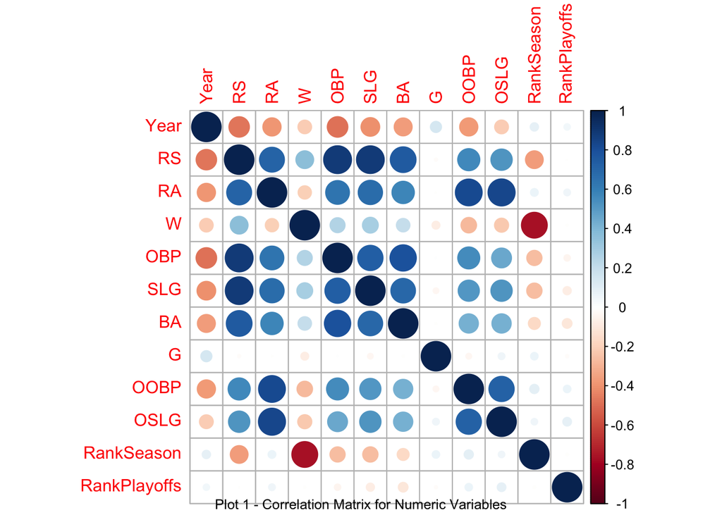

```r
# Correlation matrix for numerical variables
numeric_data <- data %>% select(Year, RS, RA, W, OBP, SLG, BA, G, OOBP, OSLG    ,RankSeason,    RankPlayoffs)
cor_matrix <- cor(numeric_data, use = "complete.obs") # Excluding missing values
corrplot(cor_matrix, method = 'circle')

# Adding title below the plot
mtext("Plot 1 - Correlation Matrix for Numeric Variables", side = 1, line = 4, cex = 0.8)
```

#### Distribution of wins

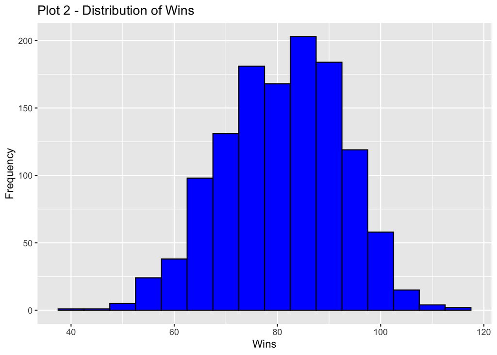

```r
# Visualizing the distribution of Wins (W)
ggplot(data, aes(x = W)) +
  geom_histogram(binwidth = 5, fill = 'blue', color = 'black') +
  labs(title = 'Plot 2 - Distribution of Wins', x = 'Wins', y = 'Frequency')
```

**Interpretation of Plot 2 - Distribution of Wins**

The histogram shows the distribution of wins across the dataset. It resembles a bell-shaped curve, which suggests a normal distribution, with most teams achieving wins in the middle range of the distribution. The highest frequency falls in the 70-90 win range, which is likely close to the mean of the distribution.

#### Scatter plot for RS vs Wins

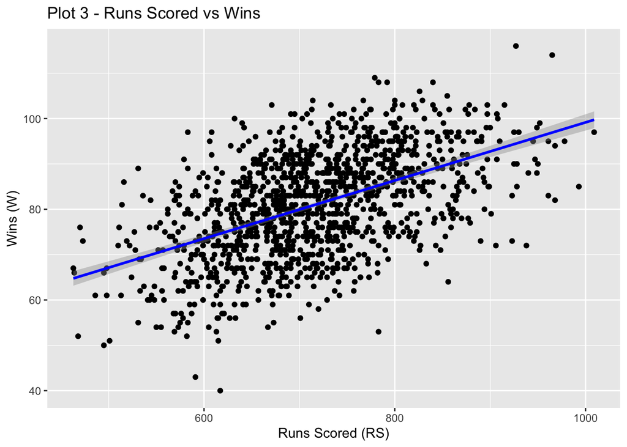

```r
# Scatter plot for Runs Scored (RS) vs Wins (W)
ggplot(data, aes(x = RS, y = W)) +
  geom_point() +
  geom_smooth(method = 'lm', col = 'blue') +
  labs(title = 'Plot 3 - Runs Scored vs Wins', x = 'Runs Scored (RS)', y = 'Wins (W)')
```

#### Boxplot comparing OBP for teams that made and didn’t make the playoffs

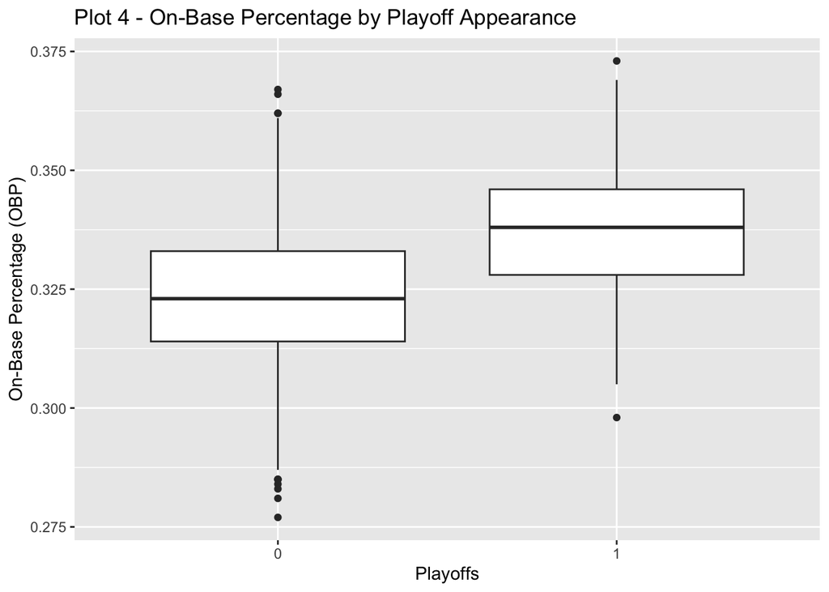

```r
# Boxplot comparing OBP for teams that made and didn't make the playoffs
ggplot(data, aes(x = as.factor(Playoffs), y = OBP)) +
  geom_boxplot() +
  labs(title = 'Plot 4 - On-Base Percentage by Playoff Appearance', x = 'Playoffs', y = 'On-Base Percentage (OBP)')
```

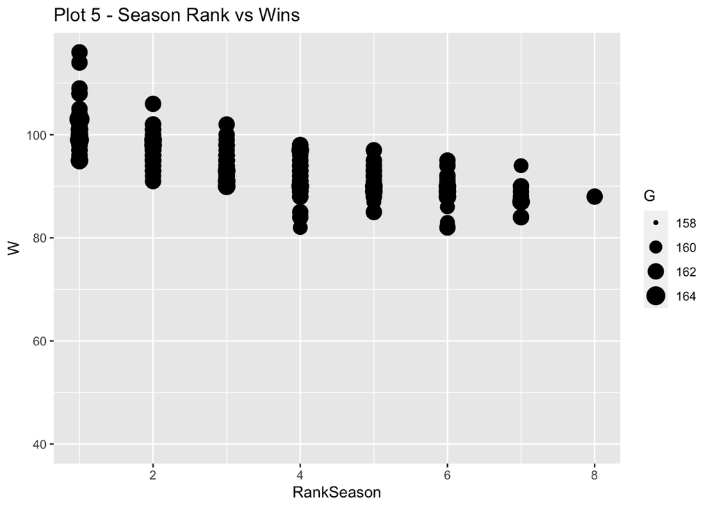

```r
# 6. Rank and Wins
ggplot(data, aes(x = RankSeason, y = W, size = G)) +
  geom_point() +
  labs(title = "Plot 5 - Season Rank vs Wins")
```

**Interpretation of Plot 5 - Season Rank vs Wins**

The scatter plot illustrates the relationship between the season rank (RankSeason) and the number of wins (W) for various teams, with the point size indicating the number of games (G) played. Higher-ranked teams tend to have more wins, but there is considerable overlap, indicating other factors may influence win totals.There are fewer data points for lower ranks, and there is no clear trend showing a relationship between the number of games played and wins or rank.

### Overall

The plots above give an insight into how different attributes are distributed and also how two attributes relate to each other.

### 9.3 Chi-Square Goodness-of-Fit test

Form the vectors of $expected$ probabilities and $observed$ frequencies, then run the test

```r
# Extract decade from year
data$Decade <- data$Year - (data$Year %% 10)
# Create a wins table by summing the wins by decade
wins <- data %>%
group_by(Decade) %>%
summarize(wins = sum(W)) %>%
as.tibble()
number_of_decades <- length(unique(data$Decade))

# Expected proportions for each decade
expected_wins <- rep(1/number_of_decades, number_of_decades)
```

### Step 1 - State the hypotheses and identify the claim

- **Null hypothesis** **H0**: There is no difference in the number of wins by decade.
- **Alternative hypothesis** **H1**: There is a difference in the number of wins by decade.

### Step 2 - Calculate critical value at alpha = 0.05

```r
critical_value <- qchisq(p = 0.95, df = length(wins$wins) - 1)
cat("Critical value at alpha = 0.05 = ",critical_value)
```

```
## Critical value at alpha = 0.05 =  11.0705
```

### Step 3 - Compute test value

```r
chi_square_test<- chisq.test(x = wins$wins, p = expected_wins)
test_value <- chi_square_test$statistic
chi_square_test
```

```
##
##  Chi-squared test for given probabilities
##
## data:  wins$wins
## X-squared = 9989.5, df = 5, p-value < 0.00000000000000022
```

```r
cat("Test value = ", test_value)
```

```
## Test value =  9989.536
```

### Step 4 - Make the decision to reject or not reject the null hypothesis

The decision rule when the $p$-value is less than $\alpha$ we should reject the null hypothesis.

$p$-value < $\alpha$ i.e. 0.00000000000000022 $<$ 0.05,so we reject $\it{H_{0}}$

The decision rule for test value is that If the *test value* exceeds the *critical value*, you would reject the null hypothesis.

Test value > critical value i.e 9989.536 > 11.0705, so we reject $\it{H_{0}}$

### Step 5 - Does comparing the critical and test values provide the same result as comparing the p-value from R with the significance level?

Yes, comparing the *critical* and *test value* provide the same result as comparing the *p-value* with *significance level*. In both the cases out final decision is to reject the Null hypothesis.

### 9.4 Download and import the dataset

```r
df_9 <- read.csv("crop_data-3.csv")
```

### 9.5 Two-way ANOVA

```r
# Convert 'density' and 'fertilizer' to factors
df_9$density <- as.factor(df_9$density)
df_9$fertilizer <- as.factor(df_9$fertilizer)

# Perform Two-way ANOVA
anova_result <- aov(yield ~ density * fertilizer, data = df_9) # (OpenAI,2024)

# Display the ANOVA table
summary(anova_result)
```

```
##                    Df Sum Sq Mean Sq F value   Pr(>F)
## density             1  5.122   5.122  15.195 0.000186 ***
## fertilizer          2  6.068   3.034   9.001 0.000273 ***
## density:fertilizer  2  0.428   0.214   0.635 0.532500
## Residuals          90 30.337   0.337
## ---
## Signif. codes:  0 '***' 0.001 '**' 0.01 '*' 0.05 '.' 0.1 ' ' 1
```

### a. Stating the hypothesis

**For density:**

- **H0**: The means of **yield** are the same across all levels of **density**.
- **H1**: At least one level of **density** has a mean of **yield** that is different from the others.

**For fertilizer:**

- **H0**: The means of **yield** are the same across all levels of **fertilizer**.
- **H1**: At least one level of **fertilizer** has a mean of **yield** that is different from the others.

**For the interaction of density and fertilizer:**

- **H0**: There is no interaction effect between **density** and **fertilizer** on **yield**.
- **H1**: There is an interaction effect between **density** and **fertilizer** on **yield**.

### b. Decision

1. **Density**:
   - **p-value (Pr(>F)):** 0.000186

   The *p-value* for density is less than 0.05 (significance level). We reject the null hypothesis (H0) that different densities do not affect yield, and accept the alternative hypothesis (H1) that different densities do affect yield.
2. **Fertilizer**:
   - **p-value (Pr(>F)):** 0.000273

   Similarly, the *p-value* for fertilizer is also **less** than **0.05**. We reject the null hypothesis that different fertilizers do not affect yield, and accept the alternative hypothesis (H1) that different fertilizers do have an effect on yield.
3. **Interaction of Density and Fertilizer**:
   - **p-value (Pr(>F)):** 0.532500

   The *p-value* for the interaction term is *greater* than 0.05, which suggests that there is no significant interaction effect between density and fertilizer on yield. We do not reject the null hypothesis for the interaction, indicating that there is not enough evidence to support the claim that the effect of fertilizer on yield depends on the density, or vice versa.

**Conclusion**: Based on the two-way **ANOVA test** conducted above, both density and fertilizer individually have a **significant** effect on yield. However, the combination of density and fertilizer **does not have a significant** interaction effect on yield. This means while each factor separately influences yield, the influence of one factor does not depend on the level of the other factor.

* Got an understanding of two-way anova from - (“Two-way ANOVA in R,” n.d.)

# Conclusion

The analyses within this module reveal diverse findings. In medical research, the distribution of blood types in a hospital did not significantly differ from the general population. Airline delay reasons varied significantly from government statistics. Movie attendance showed a dependency on ethnicity. There was a significant relationship between rank and branch for women in the military. No notable differences were found in the sodium content among various foods, nor in the sales among different company categories. Educational spending showed no significant regional differences. Lastly, in agriculture, the impact of various growth factors on plants was elucidated. Overall, these insights demonstrate the power of statistical analysis in uncovering meaningful patterns across various sectors.

# **References**

1. OpenAI. (2021). ChatGPT (Version 3.5). OpenAI.https://chat.openai.com/
2. Two-way ANOVA in R. (n.d.). Retrieved from https://statsandr.com/blog/two-way-anova-in-r/